# RStudio Examples

## Kepler Data

Our example comes from *Kepler Input Catalog (KIC) 8462852*, more famously known as *Tabby’s Star* or the “alien megastructure” star.

We are going to reproduce this star’s light curve and compare it with those of other Kepler observations to see what all the fuss was about. Primarily, we want to reproduce the light curve included in the published results.[^1]

### Set up the environment

Processed Kepler light curve data are available in FITS (Flexible Image Transport System) format. The FITS format is commonly used in astronomy, and many FITS software applications are freely available. For our purposes, there is also an R package, *FITSio*, which we can install and load using the *Packages* tab in RStudio or the following commands:

```r
# install.packages("FITSio")
library("FITSio")
```

While we’re at it, let’s load *tidyverse*, as well as some other libraries we will need.

```r
library("readr")
#library("tidyverse")
library("dplyr")
library("ggplot2")
```

With the necessary libraries loaded, we will begin by plotting a noisier version of the published light curve of KIC 8462852. We’ll step through the code in more detail below, but present the plot now to introduce the question of how is this interesting or different from the light curves of other stars.

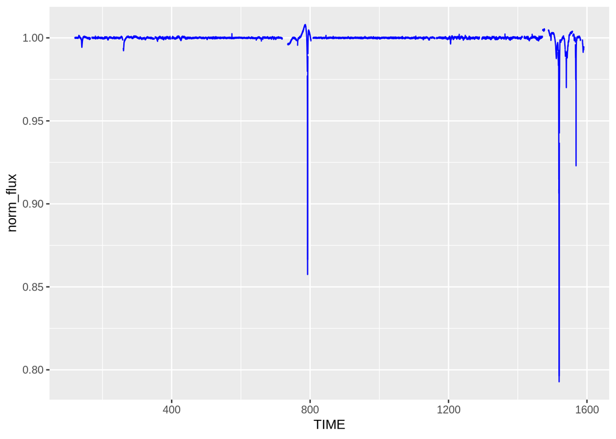

```r
files <- list.files(path="./data/kplr008462852", pattern="*.fits", full.names=TRUE, recursive=FALSE)
for (file in files){
  if (!exists("kplrdata")){
    kplrdata <- readFrameFromFITS(file, hdu = 1)
    # PDCSAP_FLUX data need to be normalized per file before appending
    dmed <- median(kplrdata$PDCSAP_FLUX, na.rm = TRUE)
    kplrdata <- kplrdata %>% mutate(norm_flux = PDCSAP_FLUX / dmed)
    rm(dmed)
  }
  if (exists("kplrdata")){
    temp_dataset <- readFrameFromFITS(file, hdu = 1)
    # PDCSAP_FLUX data need to be normalized per file before appending
    tmed <- median(temp_dataset$PDCSAP_FLUX, na.rm = TRUE)
    temp_dataset <- temp_dataset %>% mutate(norm_flux = PDCSAP_FLUX / tmed)
    kplrdata <- rbind(kplrdata, temp_dataset)
    rm(temp_dataset)
    rm(tmed)
  }
}
k8462852 <- kplrdata %>% select(TIME, PDCSAP_FLUX, norm_flux)
lc <- ggplot(k8462852, aes(TIME, norm_flux))
lc + geom_line(aes(TIME), size=0.5, color='blue')
```

```r
rm(kplrdata)
```

### Kepler Overview: Getting Data Summaries

Data for this exercise will be downloaded from the Barbara A. Mikulski Archive for Space Telescopes (MAST)[^2]

In addition to light curve data in FITS format, MAST provides a variety of catalogs and other datasets in tabular format. In order to create some meaningful contrast with KIC 8463852, it’s best to compare with other “interesting” stars. We can use various catalogs and data products to identify such stars, but will limit ourselves to one for practical purposes:

- Kepler Objects of Interest (KOI) Catalog[^3]: Includes information about candidate exoplanets and their corresponding stars.

KOI data can be exported in CSV format and has already been added to the current workspace. We can load it using the *Import Dataset* function in the IDE, or using the `read.csv` and `view` commands in the console.

Looking at the column definitions for the KOI catalog[^4], some interesting variables include

- Kepler Disposition
- NExScI Disposition
- KOI Count
- Duration
- Planet Radius
- Transit Number

We can get an overview of these variables using the *summary* and *plot* functions.

```r
summary(kois$Kepler.Disposition)
```

```
##      CANDIDATE FALSE POSITIVE
##           4496           5068
```

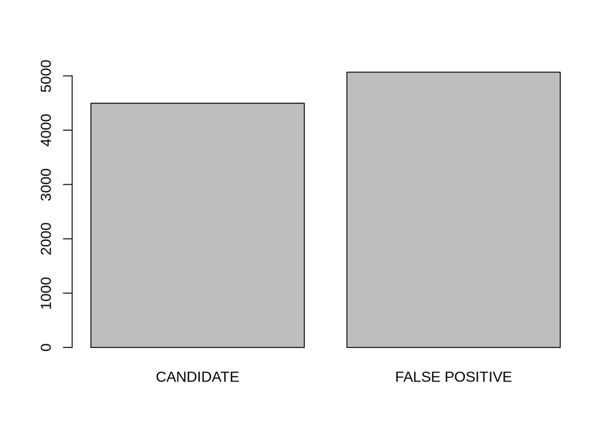

```r
plot(kois$Kepler.Disposition)
```

```r
summary(kois$NExScI.Disposition)
```

```
##      CANDIDATE      CONFIRMED FALSE POSITIVE
##           2248           2293           5023
```

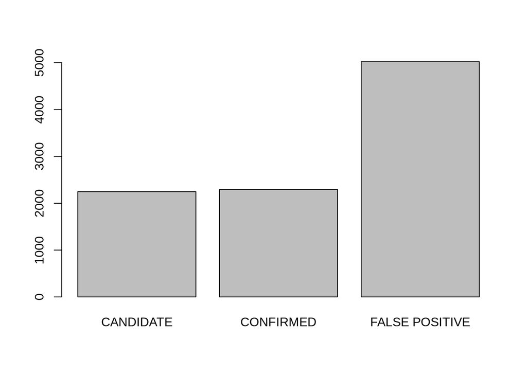

```r
plot(kois$NExScI.Disposition)
```

```r
summary(kois$KOI.count)
```

```
##    Min. 1st Qu.  Median    Mean 3rd Qu.    Max.
##   1.000   1.000   1.000   1.406   1.000   7.000
```

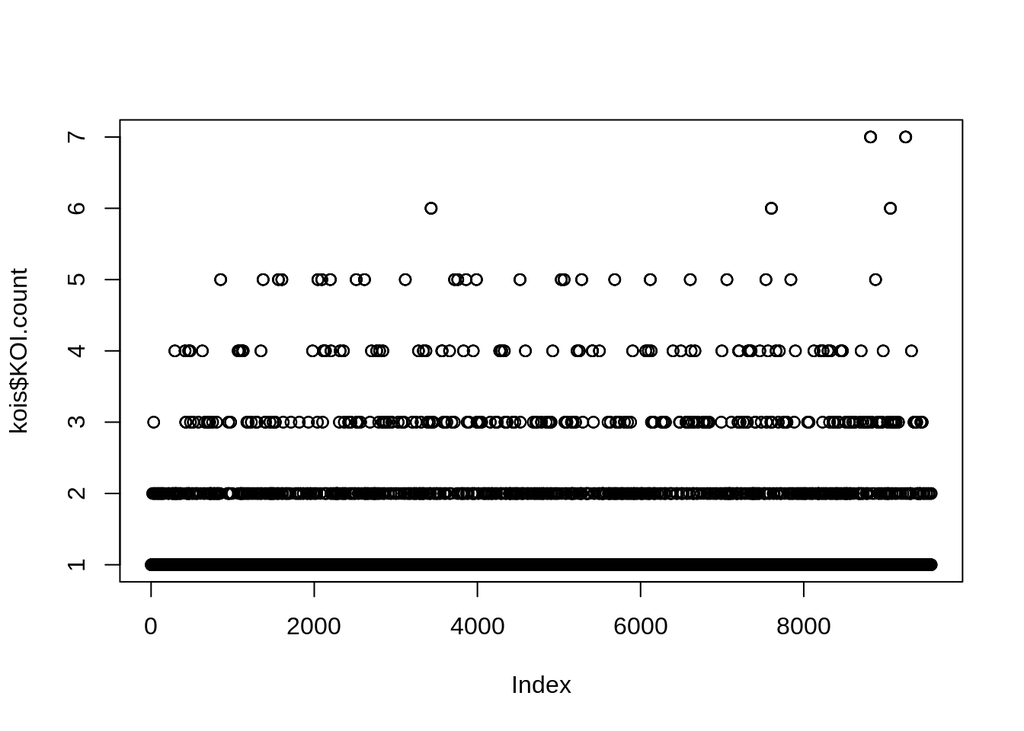

```r
plot(kois$KOI.count)
```

```r
summary(kois$Duration)
```

```
##    Min. 1st Qu.  Median    Mean 3rd Qu.    Max.
##   0.052   2.438   3.793   5.622   6.277 138.540
```

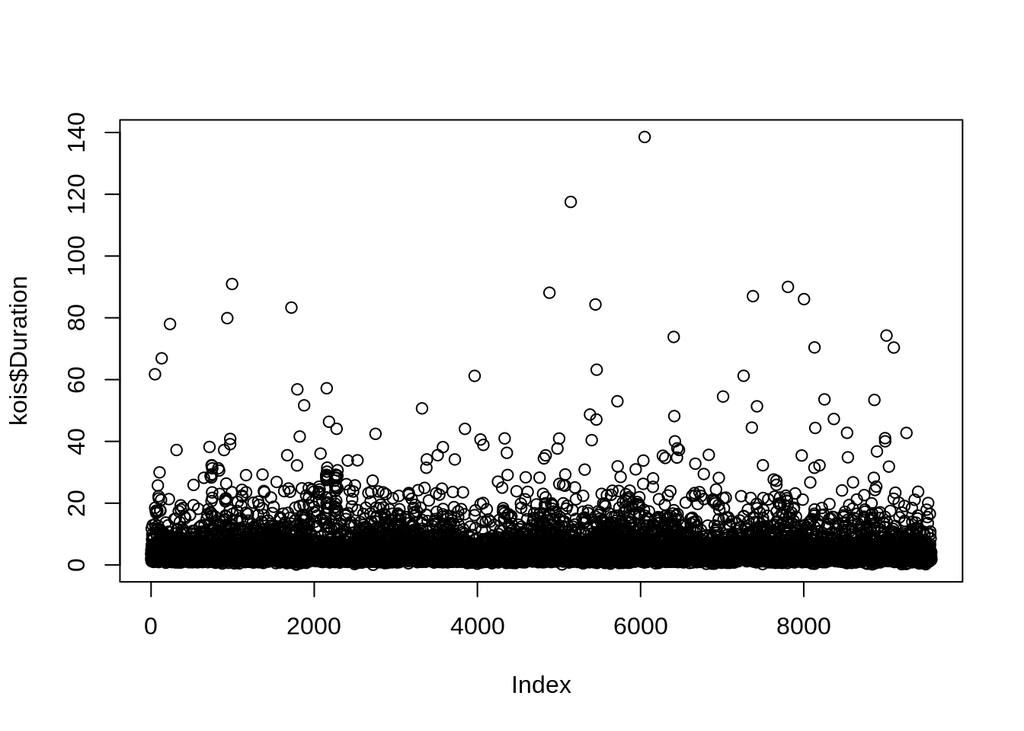

```r
plot(kois$Duration)
```

```r
summary(kois$Planet.Radius)
```

```
##      Min.   1st Qu.    Median      Mean   3rd Qu.      Max.      NA's
##      0.08      1.40      2.39    102.89     14.93 200346.00       363
```

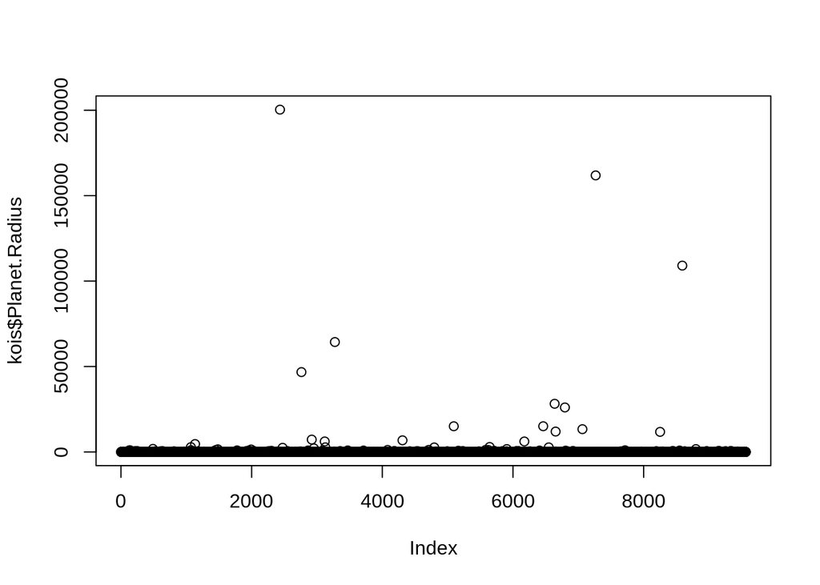

```r
plot(kois$Planet.Radius)
```

```r
summary(kois$Transit.Number)
```

```
##    Min. 1st Qu.  Median    Mean 3rd Qu.    Max.    NA's
##       0      41     143     385     469    2664    1142
```

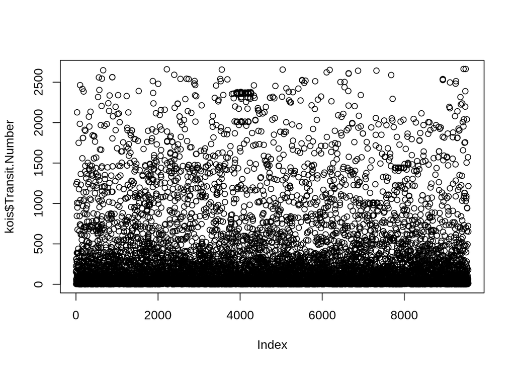

```r
plot(kois$Transit.Number)
```

### Subsetting

Let’s start by getting the KIC numbers of the stars that have 6 or more KOI.

```r
# Note the '%>%' pipe syntax for dplyr

koiCountsByID <- kois %>%
  select(Kepler.ID, KOI.count) %>% filter(KOI.count >= 6) %>%
  group_by(Kepler.ID) %>% summarise(koi_count = sum(!is.na(KOI.count)))

knitr::kable(koiCountsByID, caption = "KIC with more than 5 KOIs, by KOI count")
```

KIC with more than 5 KOIs, by KOI count

| Kepler.ID | koi_count |
| --- | --- |
| 6541920 | 6 |
| 10187017 | 6 |
| 11442793 | 7 |
| 11709124 | 6 |
| 11968463 | 7 |

That’s a more useful summary than we got above. Similarly, to limit the KOI data to these five stars, we can go back and apply the same filter to the dataset and skip the grouping and summarizing.

```r
# Use the View function to see the new dataframe in RStudio

filteredKOI <- kois %>% filter(KOI.count >= 6)

# View(filteredKOI)
```

Prior to analyzing the light curves of these stars, we can use the data we have to compare the number and size of their corresponding KOI.

For example purposes, we will begin by creating another dataframe to include only the fields or columns of interest. Where `filter` was used above to subset the data according to a given criteria, here we will use `select`.

```r
# The names funtion is useful to see column names.
names(filteredKOI)
```

```
##  [1] "Kepler.ID"             "KOI.Name"
##  [3] "Kepler.Name"           "Kepler.Disposition"
##  [5] "NExScI.Disposition"    "RA..J2000."
##  [7] "Dec..J2000."           "Time.of.Transit.Epoch"
##  [9] "Period"                "Transit.Depth"
## [11] "Duration"              "Ingress.Duration"
## [13] "Impact.Parameter"      "Inclination"
## [15] "Semi.major.Axis"       "Eccentricity"
## [17] "Long.of.Periastron"    "r.R"
## [19] "a.R"                   "Planet.Radius"
## [21] "Teq"                   "Teff"
## [23] "log.g."                "Metallicity"
## [25] "Stellar.Radius"        "Stellar.Mass"
## [27] "Age"                   "Provenance"
## [29] "Quarters"              "Transit.Number"
## [31] "KOI.count"             "Binary.Discrimination"
## [33] "Transit.Model"         "Transit.Model.SNR"
## [35] "Transit.Model.DOF"     "Transit.Model.chisq"
## [37] "Last.vet.Update"       "DV.Report"
## [39] "DV.Summary"            "Transit.Flag"
## [41] "Secondary.Flag"        "Offset.Flag"
## [43] "Contamination.Flag"    "Disposition.Score"
```

```r
compareKOI <- filteredKOI %>% select(Kepler.ID, Kepler.Disposition, NExScI.Disposition, KOI.count,
                                     Duration, Planet.Radius, Transit.Number)
# View(compareKOI)

# Get summary statistics

summary(compareKOI)
```

```
##    Kepler.ID             Kepler.Disposition      NExScI.Disposition
##  Min.   : 6541920   CANDIDATE     :29       CANDIDATE     : 6
##  1st Qu.:10187017   FALSE POSITIVE: 3       CONFIRMED     :24
##  Median :11442793                           FALSE POSITIVE: 2
##  Mean   :10453349
##  3rd Qu.:11709124
##  Max.   :11968463
##
##    KOI.count        Duration      Planet.Radius    Transit.Number
##  Min.   :6.000   Min.   : 1.188   Min.   : 0.510   Min.   :   3.0
##  1st Qu.:6.000   1st Qu.: 3.633   1st Qu.: 1.498   1st Qu.:  19.5
##  Median :6.000   Median : 4.958   Median : 2.570   Median :  57.0
##  Mean   :6.438   Mean   : 6.099   Mean   : 2.879   Mean   : 123.7
##  3rd Qu.:7.000   3rd Qu.: 7.632   3rd Qu.: 3.140   3rd Qu.: 121.5
##  Max.   :7.000   Max.   :17.489   Max.   :10.890   Max.   :1484.0
##                                                    NA's   :1
```

Note that the data still include some outliers. As we iterate through plotting the data, we can facet by disposition to separate false positives.

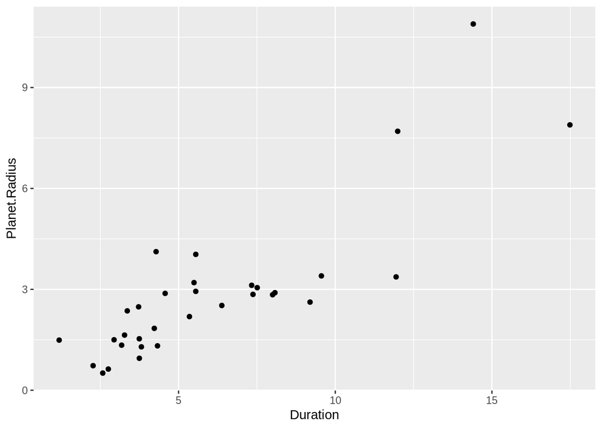

```r
# A basic ggplot, with no styling, legend, titles, etc.

koiplot <- ggplot(compareKOI, aes(Duration, Planet.Radius))

koiplot + geom_point()
```

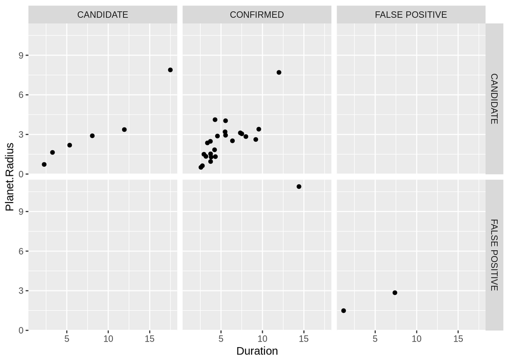

```r
koiplot + geom_point() + facet_grid(Kepler.Disposition ~ NExScI.Disposition)
```

This is an informative visualization, but still doesn’t include any representation of the number of transits recorded for each KOI. There are various ways to include this last piece of information, which we will represent using the size and/or color of the plotted observations.

#### A rogue’s gallery of iterative plots…

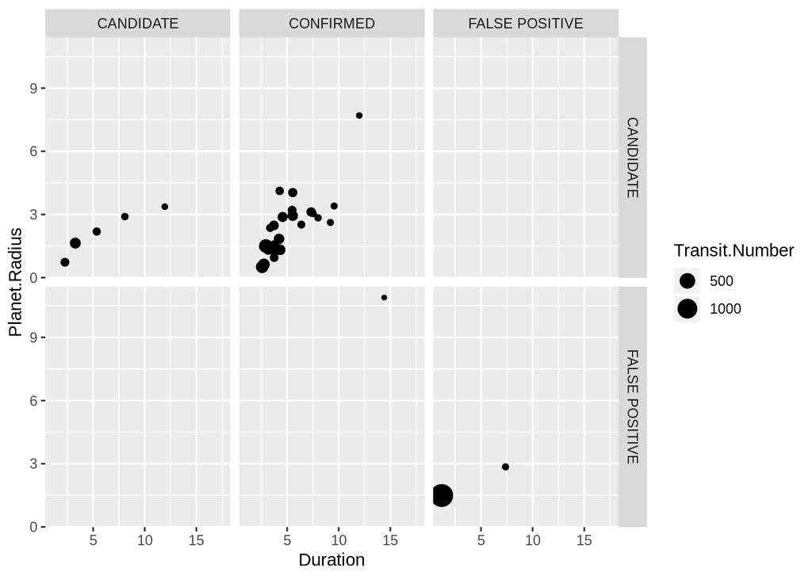

```r
koiplot + geom_point(aes(size = Transit.Number)) +
  facet_grid(Kepler.Disposition ~ NExScI.Disposition)
```

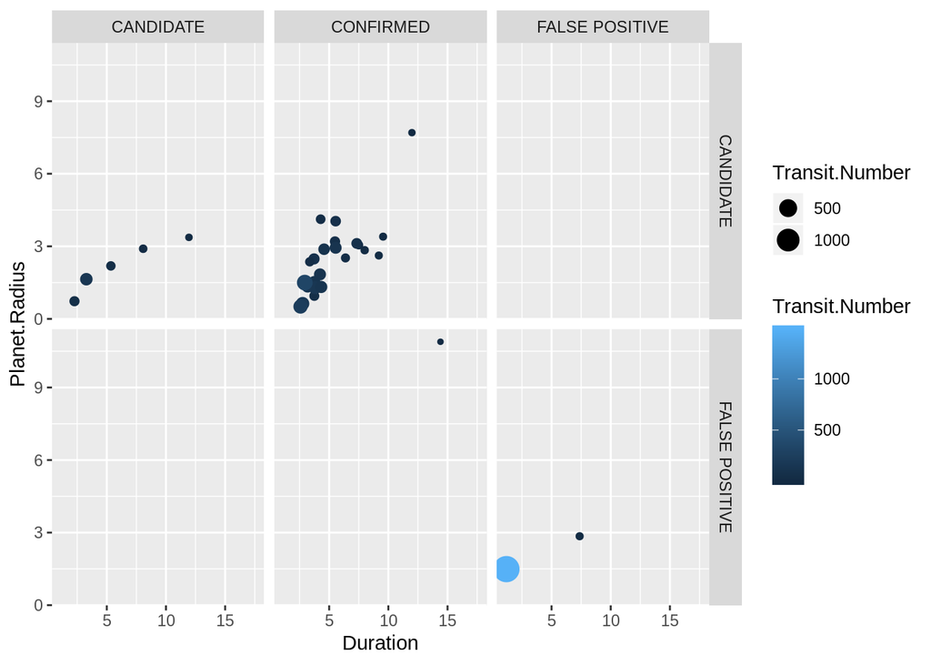

```r
koiplot + geom_point(aes(size = Transit.Number, color = Transit.Number)) +
  facet_grid(Kepler.Disposition ~ NExScI.Disposition)
```

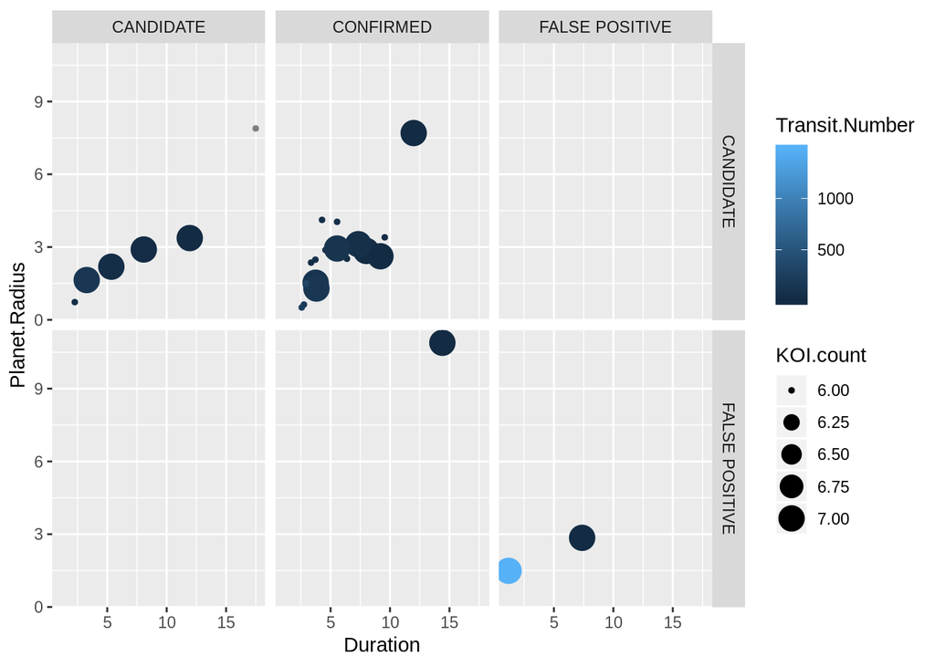

```r
koiplot + geom_point(aes(size = KOI.count, color = Transit.Number)) +
  facet_grid(Kepler.Disposition ~ NExScI.Disposition)
```

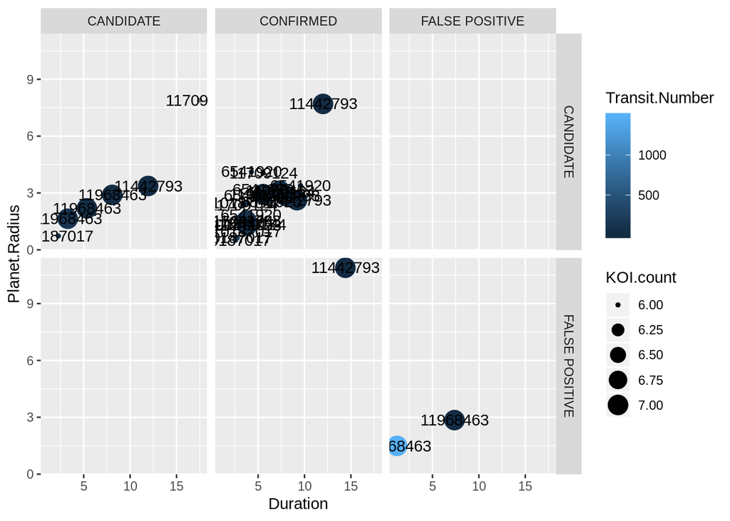

```r
koiplot + geom_point(aes(size = KOI.count, color = Transit.Number)) +
  geom_text(aes(label = Kepler.ID)) +
  facet_grid(Kepler.Disposition ~ NExScI.Disposition)
```

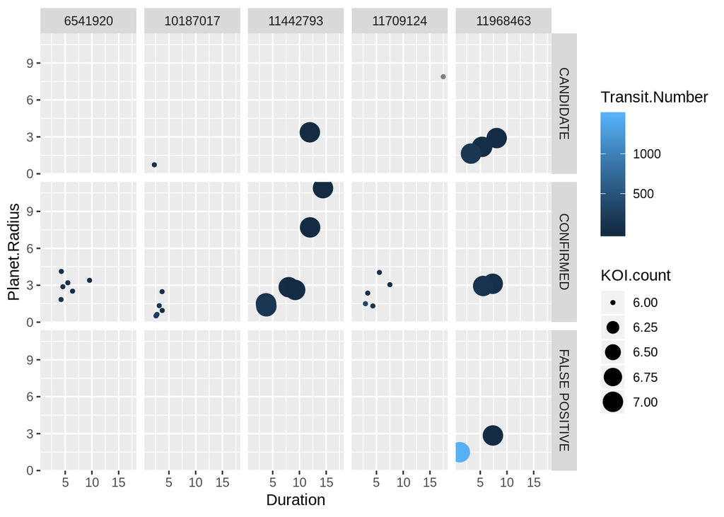

```r
koiplot + geom_point(aes(size = KOI.count, color = Transit.Number)) +
  facet_grid(NExScI.Disposition ~ Kepler.ID)
```

After various refinements, we arrive at something informative. The final plot shows us the dispositions of KOIs by star, and plots the planet radius and transit duration for each KOI. The color legend indicates the number of transits per KOI.

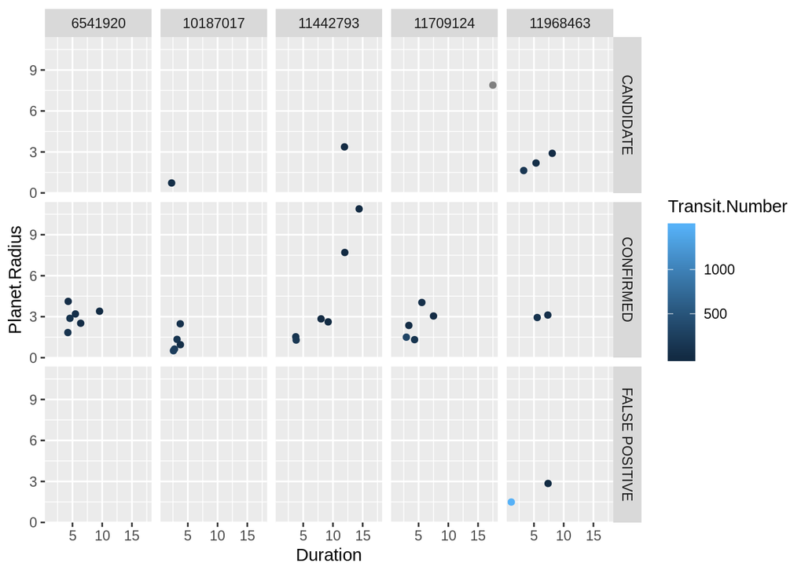

```r
koiplot + geom_point(aes(color = Transit.Number)) +
  facet_grid(NExScI.Disposition ~ Kepler.ID)
```

### Comparing light curves

To this point we have used the KOI catalog data to identify some stars which have several confirmed exoplanets of differing characteristics, under the assumption that the light curves for these stars will provide sufficient contrast with the light curve of KIC 8462852 to demonstrate why this particular star was so newsworthy.

At this point it would not be difficult or time consuming to process the light curve data for all five of the stars whose KOI data were plotted above. However, of the five there are two that seem most interesting - KIC 6541920 and KIC 11442793.

Using the terminal provided by RStudio and the `wget` scripts available from MAST, we can download the light curve data to our workspace.

```
cd data

mkdir kplr006541920

wget -q -nH --cut-dirs=6 -r -l0 -c -N -np -R 'index*' -erobots=off http://archive.stsci.edu/missions/kepler/lightcurves//0065/006541920/

cd ..

mkdir kplr011442793

cd kplr011442793

wget -q -nH --cut-dirs=6 -r -l0 -c -N -np -R 'index*' -erobots=off http://archive.stsci.edu/missions/kepler/lightcurves//0114/011442793/
```

It should be noted that there are two types of light curve files in our downloaded data - short cadence (‘slc’) and long cadence (‘llc’). In the case of KIC 8462852, only long cadence light curve data are available. We will limit our comparison to long cadence data for all three stars.

Note also that the complete wget harvest includes zip files with all the data. These are essentially duplicates for our purposes and can be deleted to save space. To save space, the short cadence data have also been deleted.

The steps to plot the light curves is the same for each star, so it makes sense to create a function that will be called each time we need it. The general syntax of an R function is

```
function_name <- function(arg1, arg2, ...){
  do stuff
  return()
}
```

The `draw_lc` function below has one argument, which is the path - really in our case the specific directory name - to the FITS data for a particular star.

Generally, the function uses `FITSio` and `dplyr` methods, but there are a couple standard R methods worth noting. The first, `list.files`, is used to generate a list of filenames that will be passed to the function.

`paste` is used to concatenate strings to set the path to the data.

`median` is used to calculate the median of the values in a column.

```r
draw_lc <- function(fpath){
  # With the directory name specified by the 'fpath' argument,
  # concatenate with './data/' for the full path. Get a list
  # of filenames in the directory.
  files <- list.files(path=paste("./data/", fpath, sep = ''),
                      pattern="*_llc.fits", full.names = TRUE, recursive =
                        FALSE)
  # For each of the files in the filelist, normalize PDCSAP_FLUX values
  # by dividing each value by the median.
  # Using the dplyr 'mutate' method, add the noralized values
  # to a new column, 'norm_flux'. The plot will be drawn from this column.
  # Append the data to the 'kplrdata' dataframe. If the dataframe
  # does not already exist, create it.
  for (file in files){
    if (!exists("kplrdata")){
      kplrdata <- readFrameFromFITS(file, hdu = 1)
      # PDCSAP_FLUX data need to be normalized per file before appending
      dmed <- median(kplrdata$PDCSAP_FLUX, na.rm = TRUE)
      kplrdata <- kplrdata %>% mutate(norm_flux = PDCSAP_FLUX / dmed)
      rm(dmed)
    }
    if (exists("kplrdata")){
      temp_dataset <- readFrameFromFITS(file, hdu = 1)
      # PDCSAP_FLUX data need to be normalized per file before appending
      tmed <- median(temp_dataset$PDCSAP_FLUX, na.rm = TRUE)
      temp_dataset <- temp_dataset %>% mutate(norm_flux = PDCSAP_FLUX / tmed)
      kplrdata <- rbind(kplrdata, temp_dataset)
      rm(temp_dataset)
      rm(tmed)
    }}
  # Return the 'kplrdata' dataframe, which includes the combined data for
  # all the files in the directory.
  return(kplrdata)
}
```

Once the dataframe consisting of all the light curve data for a particular star has been returned, the plot is drawn using the dplyr `select` method to create a smaller dataframe using only the columns of interest.

#### KIC 6541920[^5]

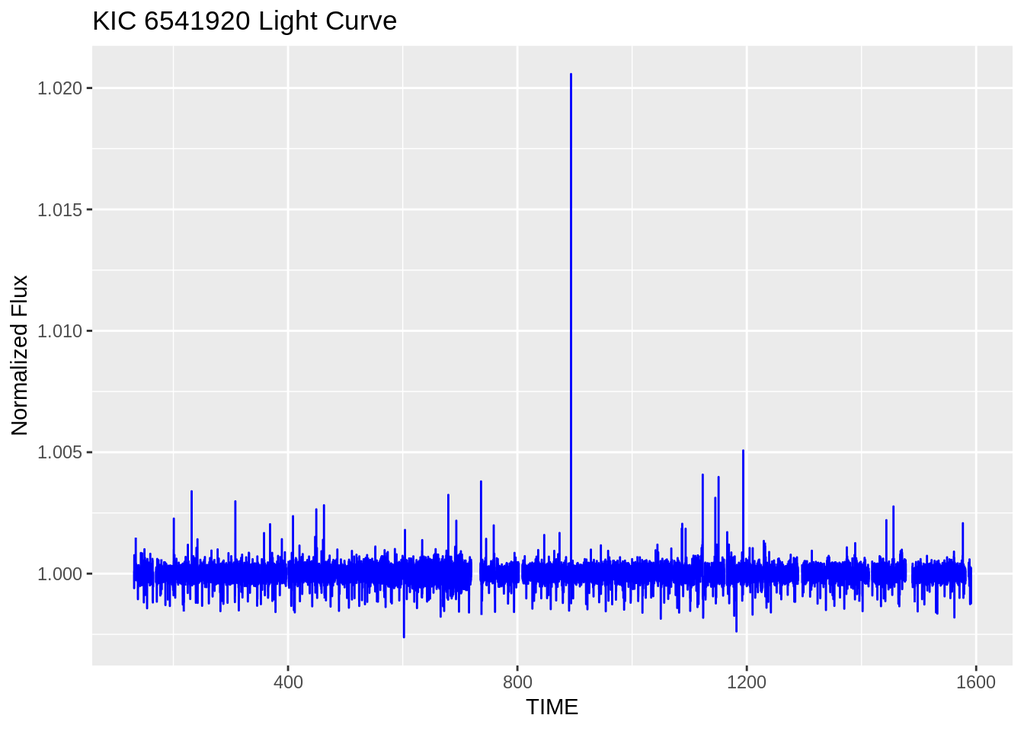

```r
kplrdata <- draw_lc("kplr006541920")
kic <- kplrdata %>% select(TIME, PDCSAP_FLUX, norm_flux)
lc <- ggplot(kic, aes(TIME, norm_flux))
lc + geom_line(aes(TIME), size=0.5, color='blue') +
  labs(title = "KIC 6541920 Light Curve", y = "Normalized Flux")
```

```r
rm(kplrdata)
```

#### KIC 11442793[^6]

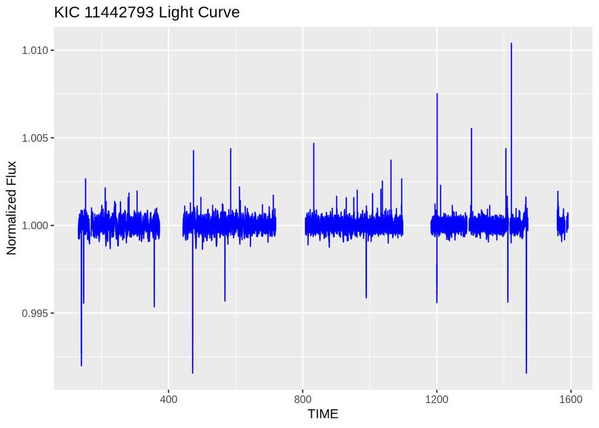

```r
kplrdata <- draw_lc("kplr011442793")
kic <- kplrdata %>% select(TIME, PDCSAP_FLUX, norm_flux)
lc <- ggplot(kic, aes(TIME, norm_flux))
lc + geom_line(aes(TIME), size=0.5, color='blue') +
  labs(title = "KIC 11442793 Light Curve", y = "Normalized Flux")
```

```r
rm(kplrdata)
```

#### KIC 8462852[^7]

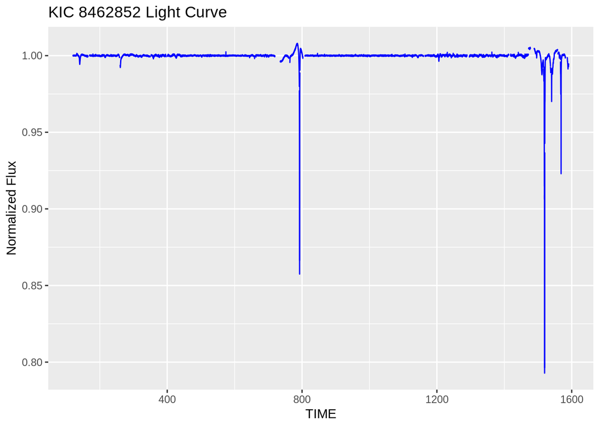

```r
kplrdata <- draw_lc("kplr008462852")
kic <- kplrdata %>% select(TIME, PDCSAP_FLUX, norm_flux)
lc <- ggplot(kic, aes(TIME, norm_flux))
lc + geom_line(aes(TIME), size=0.5, color='blue') +
  labs(title = "KIC 8462852 Light Curve", y = "Normalized Flux")
```

```r
rm(kplrdata)
```

## Acknowledgments

Some/all of the data presented in this notebook were obtained from the Mikulski Archive for Space Telescopes (MAST). STScI is operated by the Association of Universities for Research in Astronomy, Inc., under NASA contract NAS5-26555.

This notebook includes data collected by the Kepler mission. Funding for the Kepler mission is provided by the NASA Science Mission directorate.

## References and Data

[^1]: Boyajian, T. S.; LaCourse, D. M.; Rappaport, S. A.; Fabrycky, D.; Fischer, D. A.; et al. (April 2016). “Planet Hunters IX. KIC 8462852 – where’s the flux?”. Monthly Notices of the Royal Astronomical Society. 457 (4): 3988–4004. arXiv:1509.03622v2 [astro-ph.SR]. doi:10.1093/mnras/stw218.
[^2]: Barbara A. Mikulski Archive for Space Telescopes. Accessed 2018-09-13. http://archive.stsci.edu/index.html
[^3]: kepler_stellar17 [dataset]. Accessed 2018-09-14. https://archive.stsci.edu/missions/kepler/catalogs/kepler_steller_17.csv.gz
[^4]: Barbara A. Mikulski Archive for Space Telescopes. “KEPLER_KOI.” Accessed 2018-09-13. http://archive.stsci.edu/kepler/koi/help/columns.html
[^5]: Kepler light curve, KIC 6541920 [dataset]. Accessed 2018-09-14. http://archive.stsci.edu/missions/kepler/lightcurves//0065/006541920/
[^6]: Kepler light curve, KIC 11442793 [dataset]. Accessed 2018-09-14. http://archive.stsci.edu/missions/kepler/lightcurves//0114/011442793/
[^7]: Kepler light curve, KIC 8462852 [dataset]. Accessed 2018-09-14. http://archive.stsci.edu/missions/kepler/lightcurves//0084/008462852/